# 成為初級資料分析師 | Python 機器學習

> NumPy 101

## 郭耀仁

## 大綱

- NumPy 起步走
- 陣列處理
- 陣列運算

## NumPy 起步走

## 什麼是 NumPy？

> NumPy is the fundamental package for scientific computing in Python. It is a Python library that provides a multidimensional array object, various derived objects (such as masked arrays and matrices), and an assortment of routines for fast operations on arrays, including mathematical, logical, shape manipulation, sorting, selecting, I/O, discrete Fourier transforms, basic linear algebra, basic statistical operations, random simulation and much more.

## NumPy: Numerical Python

- 創建一種稱為 ndarray 的類別，彌補了原生 list 缺少的向量化運算（vectorization）功能
- ndarray：N-dimensional array，具備高速向量化的特性

## 安裝與載入 NumPy

- 安裝

```
# run in bash shell
pip install numpy
```

- 載入

```
# run in python console
import numpy as np
```

## 如何創建 ndarray: `np.array()`

- 由既有的 list 轉換而成
- 可搭配 `dtype` 參數指定資料型態

```python
import numpy as np

homogeneous_list = [1, 2, 3, 4, 5]
arr = np.array(homogeneous_list, dtype=int)
print(arr.dtype)
arr = np.array(homogeneous_list, dtype=float)
print(arr.dtype)
```

```
int64
float64
```

## 使用多樣式的 NumPy 函數直接創建

- `np.zeros(shape)` 創建指定外觀充滿 0 的數值陣列
- `np.ones(shape)` 創建指定外觀充滿 1 的數值陣列
- `np.full(shape, fill_value)` 創建指定外觀充滿 fill_value 的數值陣列

## 使用多樣式的 NumPy 函數直接創建

- `np.arange(start, stop, step)` 創建從 start （包含）間隔 step 至 stop （不包含）的等差數列，使用方式同內建函數 `range()`
- `np.linspace(start, stop, num)` 創建從 start （包含）至 stop （包含）的均勻切割為 num 個資料點的數值陣列

## 使用多樣式的 NumPy 函數直接創建

- `np.random.random(size)` 創建符合均勻分布的隨機數值陣列
- `np.random.normal(loc, scale, size)` 創建符合常態分布的隨機數值陣列
- `np.random.randint(low, high, size)` 創建介於 `low` 與 `high` 之間的隨機數值陣列

## 與標準套件 `random` 功能相仿的 `np.random`

- `np.random.seed()` 設定隨機種子，在相同的整數設定下可以消弭隨機性
- `np.random.choice(size, replace, p)` 抽樣
- `np.random.shuffle()` 隨意排序

## ndarray 的屬性

- `arr.ndim` ：檢視 arr 有幾個維度
- `arr.shape` ：檢視 arr 的外型
- `arr.size` ：檢視 arr 的資料筆數，對一維陣列的意涵就像內建函數 `len()` 作用在 list 上一般
- `arr.dtype` ：檢視 arr 中同質資料的型態

## 陣列處理

## 重塑外觀

- `arr.reshape(m, n, ...)` 將數值陣列重塑成運算所需要的外觀
- `arr.ravel()` 將外觀為 (m, n, …) 的數值陣列調整回一維

```python
arr = np.arange(25)
print(arr.reshape(5, 5))
print(arr.ravel())
```

```
[[ 0  1  2  3  4]
 [ 5  6  7  8  9]
 [10 11 12 13 14]
 [15 16 17 18 19]
 [20 21 22 23 24]]
[ 0  1  2  3  4  5  6  7  8  9 10 11 12 13 14 15 16 17 18 19 20 21 22 23
 24]
```

```python
arr = np.arange(25)
# reshape conveniently
print(arr.reshape(5, -1))
print(arr.reshape(-1, 5))
```

```
[[ 0  1  2  3  4]
 [ 5  6  7  8  9]
 [10 11 12 13 14]
 [15 16 17 18 19]
 [20 21 22 23 24]]
[[ 0  1  2  3  4]
 [ 5  6  7  8  9]
 [10 11 12 13 14]
 [15 16 17 18 19]
 [20 21 22 23 24]]
```

## 從 ndarray 中取出單個資料值的方式與 list 相同，使用 arr[INDEX] 取值

```python
arr = np.arange(25)
print(arr[12])
```

```
12
```

## 面對二維以上的陣列，ndarray 支援使用 `[i, j, …]` 的方式取出位於第 i 列（row）、第 j 欄（column）… 的資料

```python
arr = np.arange(25).reshape(5, -1)
print(arr[2, 2])
```

```
12
```

## 使用吐司麵包來理解多維陣列

- 一維陣列（向量）：吐司條
- 二維陣列（矩陣）：一片吐司
- 三維陣列（張量）：一包吐司
- 四維陣列（張量）：擺在架上的多包吐司

## 吐司條

[figure not shown]

## 一片吐司

[figure not shown]

## 一包吐司

[figure not shown]

## 擺在架上的多包吐司

[figure not shown]

## ndarray 類別與 `list` 的差異

> At the core of the NumPy package, is the ndarray object. This encapsulates n-dimensional arrays of homogeneous data types, with many operations being performed in compiled code for performance.
- 僅能容納相同的資料類型
- 具有特殊的索引功能：fancy indexing/boolean indexing

## 僅能容納相同的資料類型

```python
arr = np.arange(25).reshape(5, -1)
arr[2, 2] = False
print(arr)
```

```
[[ 0  1  2  3  4]
 [ 5  6  7  8  9]
 [10 11  0 13 14]
 [15 16 17 18 19]
 [20 21 22 23 24]]
```

## 具有特殊的索引功能

- Fancy indexing
- Boolean indexing

## 華麗索引（Fancy indexing）指的是以陣列傳入不規則的索引值選取資料值，不用遷就 arr[start:stop:step] 的規則

```python
arr = np.arange(1, 14)
prime_indices = [1, 2, 4, 6, 10, 12]
print(arr[prime_indices])
```

```
[ 2  3  5  7 11 13]
```

## 布林索引（Boolean indexing）指的是以外觀相同的陣列傳入布林值，將位置為 `True` 的資料篩選出來

```python
arr = np.arange(1, 14)
is_odd = arr % 2 == 1
print(is_odd)
print(arr[is_odd])
```

```
[ True False  True False  True False  True False  True False  True False
  True]
[ 1  3  5  7  9 11 13]
```

## 複製陣列

ndarray 有一個重要的預設特性稱為「不複製」，因此不論在切割或重新宣告的情境中都是創建陣列的 View，而非複製另一個陣列，這代表著對以 View 型式存在的子陣列（Sub-array）更新會改動到原始陣列

```python
arr = np.arange(1, 10)
mat = arr.reshape(3, 3)
mat[1, 1] = 5566
print(mat)
print(arr)
```

```
[[   1    2    3]
 [   4 5566    6]
 [   7    8    9]]
[   1    2    3    4 5566    6    7    8    9]
```

## 若希望實踐陣列的複製，可以運用其 `.copy()` 方法

```python
arr = np.arange(1, 10)
mat = arr.copy()
mat = mat.reshape(3, 3)
mat[1, 1] = 5566
print(mat)
print(arr)
```

```
[[   1    2    3]
 [   4 5566    6]
 [   7    8    9]]
[1 2 3 4 5 6 7 8 9]
```

## 合併陣列

- `np.concatenate([arr0, arr1, ...], axis)`
  - `axis=0`: 垂直合併
  - `axis=1`: 水平合併

```python
arr_a = np.arange(1, 5).reshape(2, 2)
arr_b = np.arange(5, 9).reshape(2, 2)
print(np.concatenate([arr_a, arr_b]))
print(np.concatenate([arr_a, arr_b], axis=1))
```

```
[[1 2]
 [3 4]
 [5 6]
 [7 8]]
[[1 2 5 6]
 [3 4 7 8]]
```

## 使用 `np.append()` 實踐類似 `list` 的 `.append()` 方法

```python
arr = np.array([])
for i in range(10):
    arr = np.append(arr, i)
print(arr)
```

```
[0. 1. 2. 3. 4. 5. 6. 7. 8. 9.]
```

## 使用 `np.transpose()` 進行陣列的轉置

```python
arr = np.arange(24).reshape(3, 8)
print(arr)
print(np.transpose(arr))
```

```
[[ 0  1  2  3  4  5  6  7]
 [ 8  9 10 11 12 13 14 15]
 [16 17 18 19 20 21 22 23]]
[[ 0  8 16]
 [ 1  9 17]
 [ 2 10 18]
 [ 3 11 19]
 [ 4 12 20]
 [ 5 13 21]
 [ 6 14 22]
 [ 7 15 23]]
```

## 以 `np.where()` 搭配 Fancy indexing 實踐內建函式 `filter()`

```python
arr = np.arange(11, 21)
np.random.shuffle(arr)
print(arr)
odds = arr[np.where(arr % 2 == 1)]
print(odds)
```

```
[20 17 14 12 11 18 15 19 13 16]
[17 11 15 19 13]
```

## 以 `np.meshgrid()` 建立網格陣列

```python
x = np.array([1, 2, 3])
y = np.array([4, 5, 6])
xx, yy = np.meshgrid(x, y)
print(xx)
print(yy)
```

```
[[1 2 3]
 [1 2 3]
 [1 2 3]]
[[4 4 4]
 [5 5 5]
 [6 6 6]]
```

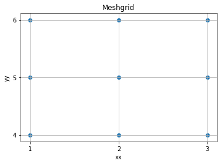

```python
plot_meshgrid(xx, yy)
```

## 陣列運算

## ndarray 的運算種類

- 透過 NumPy 的通用函數（Universal Functions）與聚合函數（Aggregate Functions）運算數值陣列
- 透過 `np.linalg` 運算

## 我們可以使用 `%timeit` 得知若想以迭代對一百萬筆隨機整數進行「倒數」的運算要花多少時間

```python
long_arr = np.random.randint(1, 101, size=1000000)
%timeit [1/i for i in long_arr]
```

```
396 ms ± 52 ms per loop (mean ± std. dev. of 7 runs, 1 loop each)
```

## 使用 ndarray 的通用函數運算，就像是利用已經編譯過的程式對固定物件類型計算，效率較高

```python
%timeit np.divide(1, long_arr)
```

```
2.07 ms ± 169 µs per loop (mean ± std. dev. of 7 runs, 100 loops each)
```

## 基礎通用函數與純量的數值運算符相同

- `np.add()` ：同 `+` 運算符
- `np.subtract()` ：同 `-` 運算符
- `np.multiply()` ：同 `*` 運算符
- `np.divide()` ：同 `/` 運算符
- `np.power()` ：同 `**` 運算符
- `np.floor_divide()` ：同 `//` 運算符
- `np.mod()` ：同 `%` 運算符

## 假如希望對數值陣列使用的通用函數是為自己需求量身訂製的，這時可以將函數定義後以 `np.vectorize()` 轉換為一個通用函數

```python
def is_prime(x):
    div_cnt = 0
    for i in range(1, x+1):
        if x % i == 0:
            div_cnt += 1
        if div_cnt > 2:
            break
    return div_cnt == 2
```

```python
is_prime_ufunc = np.vectorize(is_prime)
arr = np.arange(1, 21)
print(arr)
print(is_prime_ufunc(arr))
print(arr[is_prime_ufunc(arr)])
```

```
[ 1  2  3  4  5  6  7  8  9 10 11 12 13 14 15 16 17 18 19 20]
[False  True  True False  True False  True False False False  True False
  True False False False  True False  True False]
[ 2  3  5  7 11 13 17 19]
```

## 聚合函數

通用與聚合函數最大差異點就在於輸入與輸出的數值陣列長度，不同於通用函數，聚合函數所輸出的數值陣列多數僅有長度 1，或遠小於輸入數值陣列的長度。

## 聚合函數的兩個特性

- 能沿指定維度聚合
- 多數具有可運算遺漏值的相對應函數

## 能沿指定維度聚合

```python
arr = np.arange(1, 16).reshape(3, 5).astype(float)
print(arr)
print(np.sum(arr)) # 1 個輸出
print(np.sum(arr, axis=0)) # 5 個輸出
print(np.sum(arr, axis=1)) # 3 個輸出
```

```
[[ 1.  2.  3.  4.  5.]
 [ 6.  7.  8.  9. 10.]
 [11. 12. 13. 14. 15.]]
120.0
[18. 21. 24. 27. 30.]
[15. 40. 65.]
```

## 多數具有可運算遺漏值的相對應函數

- np.sum 與 np.nansum
- np.prod 與 np.nanprod
- np.mean 與 np.nanmean
- np.median 與 np.nanmedian
- np.std 與 np.nanstd
- np.var 與 np.nanvar
- np.min 與 np.nanmin
- np.max 與 np.nanmax
- np.argmin 與 np.nanargmin
- np.argmax 與 np.nanargmax

```python
arr[2, 4] = np.nan
print(arr)
print(np.sum(arr))
print(np.nansum(arr))
```

```
[[ 1.  2.  3.  4.  5.]
 [ 6.  7.  8.  9. 10.]
 [11. 12. 13. 14. nan]]
nan
105.0
```

## 隨堂練習：計算 $x$ 的變異數

$$Var(x) = \frac{1}{N}\sum_{n=1}^{N}(x_n - \bar{x})^2$$

```python
x = np.random.randint(0, 50, 10)
```

```python
N = x.size
x_bar = np.mean(x)
var_x = np.divide(np.sum(np.power(x - x_bar, 2)), N)
print(var_x)
```

```
205.01
```

## 使用 `np.var()` 計算變異數

```python
var_x = np.var(x)
print(var_x)
```

```
205.01
```

## 使用 `np.std()` 計算標準差

$$SD(x) = \sqrt{\frac{1}{N}\sum_{n=1}^{N}(x_n - \bar{x})^2}$$

```python
std_x = np.std(x)
print(std_x)
print(var_x**0.5)
```

```
14.31817027416562
14.31817027416562
```

## 隨堂練習：計算 $x$ 與 $y$ 的共變異數

$$cov(x, y) = \frac{1}{N}\sum_{n=1}^{N}(x_n-\bar{x})(y_n-\bar{y})$$

```python
x = np.random.randint(0, 50, 10)
y = np.random.randint(0, 50, 10)
```

```python
N = x.size
x_bar = np.mean(x)
y_bar = np.mean(y)
cov_xy = np.divide(np.sum((x - x_bar)*(y - y_bar)), N)
print(cov_xy)
```

```
-27.26
```

## 使用 `np.cov()` 計算可得共變異數矩陣

$$\Sigma = \begin{pmatrix} cov(x, x) & cov(x, y) \\ cov(y, x) & cov(y, y) \\ \end{pmatrix} \\ $$

```python
print(np.cov(x, y, ddof=0))
print(np.var(x))
print(np.var(y))
```

```
[[140.21 -27.26]
 [-27.26 225.36]]
140.20999999999998
225.35999999999999
```

## 隨堂練習：計算 $x$ 與 $y$ 的相關係數 $r_{xy}$

$$r_{xy} = \frac{cov(x, y)}{\sqrt{cov(x, x)cov(y, y)}}$$

```python
x = np.random.randint(0, 50, 10)
y = np.random.randint(0, 50, 10)
```

```python
cov_xy = np.cov(x, y)
r_xy = cov_xy[0, 1] / np.sqrt(cov_xy[0, 0]*cov_xy[1, 1])
print(r_xy)
```

```
-0.06147481330810518
```

## 使用 `np.corrcoef()` 計算可得相關係數矩陣

$$ R = \begin{pmatrix} r_{xx} & r_{xy} \\ r_{yx} & r_{yy} \\ \end{pmatrix} \\ $$

```python
R_xy = np.corrcoef(x, y)
print(R_xy)
```

```
[[ 1.         -0.06147481]
 [-0.06147481  1.        ]]
```

## 使用 `np.dot()` 進行向量的內積或矩陣的相乘

```python
# vector dot
arr_a = np.array([1, 2, 3])
arr_b = np.array([4, 5, 6])
print(np.dot(arr_a, arr_b))
```

```
32
```

```python
# matrix dot
arr_a = np.arange(1, 5).reshape(2, 2)
arr_b = np.arange(4, 0, -1).reshape(2, 2)
print(arr_a)
print(arr_b)
print(np.dot(arr_a, arr_b))
```

```
[[1 2]
 [3 4]]
[[4 3]
 [2 1]]
[[ 8  5]
 [20 13]]
```

## 透過 `np.eye()` 創建單位矩陣

`np.eye()` 諧音 identity matrix.

```python
I = np.eye(2)
print(I)
```

```
[[1. 0.]
 [0. 1.]]
```

## 包含常用矩陣運算的 `np.linalg`

- `np.linalg.det()` 計算矩陣的行列式
- `np.linalg.inv()` 計算矩陣的反矩陣

## 2x2 反矩陣的算法

$$ AA^{-1} = I \\ A = \begin{pmatrix} a_{11} & a_{12} \\ a_{21} & a_{22} \\ \end{pmatrix} \\ A^{-1} = \frac{1}{detA}\begin{pmatrix} a_{22} & -a_{12} \\ -a_{21} & a_{11} \\ \end{pmatrix} $$

```python
A = np.array([
    [6, 7],
    [2, 4]
], dtype=float)
det_A = np.linalg.det(A)
adj_A = np.array([
    [A[1, 1], -A[0, 1]],
    [-A[1, 0], A[0, 0]]
])
inv_A = (1/det_A)*adj_A
print(inv_A)
print(np.dot(A, inv_A))
```

```
[[ 0.4 -0.7]
 [-0.2  0.6]]
[[ 1.00000000e+00 -2.22044605e-16]
 [ 0.00000000e+00  1.00000000e+00]]
```

```python
inv_A = np.linalg.inv(A)
print(inv_A)
print(np.dot(A, inv_A))
```

```
[[ 0.4 -0.7]
 [-0.2  0.6]]
[[ 1.00000000e+00 -2.22044605e-16]
 [ 0.00000000e+00  1.00000000e+00]]
```